# 피마 인디언 당뇨병 데이터베이스

Doyoung Kim

2022-08-08

# 당뇨병

#### 혈액 속의 포도당이 세포 속으로 들어가 에너지원으로 이용되지 못하여 혈당이 비정상적으로 올라가는 질환

### 1) 탄수화물 섭취하면 위장에서 소화효소에 의해 탄수화물의 기본 구성성분인 포도당으로 변한 다음 혈액으로 흡수

### 2) 포도당은 기본적인 에너지원. 흡수된 포도당이 세포들에서 이용되기 위해 인슐린 호르몬이 필요

### 3) 인슐린은 췌장의 베타세포에서 분비되어 식사 후 올라간 혈당을 낮추는 기능

### 자료 출처

##### https://www.kaggle.com/datasets/uciml/pima-indians-diabetes-database

### 변수

##### Pregnancies: 임신 횟수

##### Glucose: 포도당 부하 검사 수치

##### BloodPressure: 혈압(mm Hg)

##### SkinThickness: 팔 삼두근 뒤쪽의 피하지방 측정값(mm)

##### Insulin: 혈청 인슐린(mu U/ml)

##### BMI: 체질량지수(체중(kg)/키(m))^2

##### DiabetesPedigreeFunction: 당뇨 내력 가중치 값

##### Age: 나이

##### Outcome: 클래스 결정 값(0 또는 1)

## 파일 로딩 및 기본 정보 확인

```r
df <- read.csv('./diabetes/diabetes.csv')
str(df)
```

```
## 'data.frame':    768 obs. of  9 variables:
##  $ Pregnancies             : int  6 1 8 1 0 5 3 10 2 8 ...
##  $ Glucose                 : int  148 85 183 89 137 116 78 115 197 125 ...
##  $ BloodPressure           : int  72 66 64 66 40 74 50 0 70 96 ...
##  $ SkinThickness           : int  35 29 0 23 35 0 32 0 45 0 ...
##  $ Insulin                 : int  0 0 0 94 168 0 88 0 543 0 ...
##  $ BMI                     : num  33.6 26.6 23.3 28.1 43.1 25.6 31 35.3 30.5 0 ...
##  $ DiabetesPedigreeFunction: num  0.627 0.351 0.672 0.167 2.288 ...
##  $ Age                     : int  50 31 32 21 33 30 26 29 53 54 ...
##  $ Outcome                 : int  1 0 1 0 1 0 1 0 1 1 ...
```

## 범주형으로 형 변환

```r
df$Outcome <- factor(df$Outcome)
str(df)
```

```
## 'data.frame':    768 obs. of  9 variables:
##  $ Pregnancies             : int  6 1 8 1 0 5 3 10 2 8 ...
##  $ Glucose                 : int  148 85 183 89 137 116 78 115 197 125 ...
##  $ BloodPressure           : int  72 66 64 66 40 74 50 0 70 96 ...
##  $ SkinThickness           : int  35 29 0 23 35 0 32 0 45 0 ...
##  $ Insulin                 : int  0 0 0 94 168 0 88 0 543 0 ...
##  $ BMI                     : num  33.6 26.6 23.3 28.1 43.1 25.6 31 35.3 30.5 0 ...
##  $ DiabetesPedigreeFunction: num  0.627 0.351 0.672 0.167 2.288 ...
##  $ Age                     : int  50 31 32 21 33 30 26 29 53 54 ...
##  $ Outcome                 : Factor w/ 2 levels "0","1": 2 1 2 1 2 1 2 1 2 2 ...
```

## 결측치 확인

```r
sum(is.na(df))
```

```
## [1] 0
```

```r
summary(df)
```

```
##   Pregnancies        Glucose      BloodPressure    SkinThickness
##  Min.   : 0.000   Min.   :  0.0   Min.   :  0.00   Min.   : 0.00
##  1st Qu.: 1.000   1st Qu.: 99.0   1st Qu.: 62.00   1st Qu.: 0.00
##  Median : 3.000   Median :117.0   Median : 72.00   Median :23.00
##  Mean   : 3.845   Mean   :120.9   Mean   : 69.11   Mean   :20.54
##  3rd Qu.: 6.000   3rd Qu.:140.2   3rd Qu.: 80.00   3rd Qu.:32.00
##  Max.   :17.000   Max.   :199.0   Max.   :122.00   Max.   :99.00
##     Insulin           BMI        DiabetesPedigreeFunction      Age
##  Min.   :  0.0   Min.   : 0.00   Min.   :0.0780           Min.   :21.00
##  1st Qu.:  0.0   1st Qu.:27.30   1st Qu.:0.2437           1st Qu.:24.00
##  Median : 30.5   Median :32.00   Median :0.3725           Median :29.00
##  Mean   : 79.8   Mean   :31.99   Mean   :0.4719           Mean   :33.24
##  3rd Qu.:127.2   3rd Qu.:36.60   3rd Qu.:0.6262           3rd Qu.:41.00
##  Max.   :846.0   Max.   :67.10   Max.   :2.4200           Max.   :81.00
##  Outcome
##  0:500
##  1:268
##
##
##
##
```

## 0 <- NA로 바꾸기

```r
df$Glucose[df$Glucose==0] <- NA
df$BloodPressure[df$BloodPressure==0] <- NA
df$SkinThickness[df$SkinThickness==0] <- NA
df$BMI[df$BMI==0] <- NA
```

## 결측치 그래프

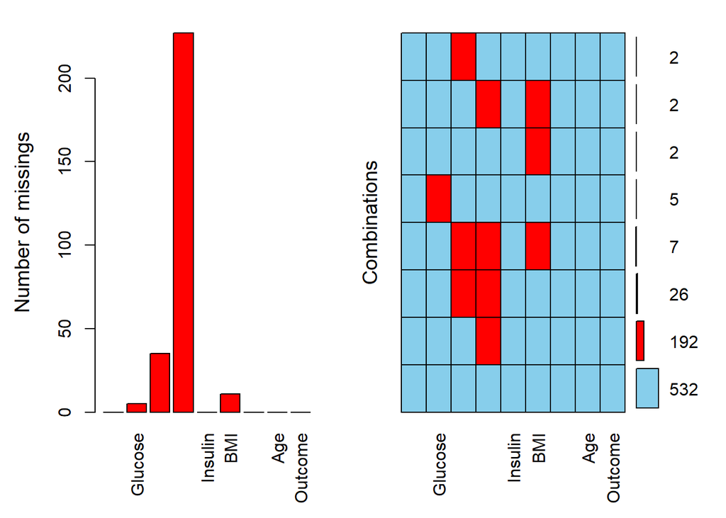

```r
library(VIM)
aggr(df, numbers=T, prop=F)
```

## 정상과 환자 구분하여 NA <- 각 변수 평균으로 채우기

```r
df$Glucose[is.na(df$Glucose) & df$Outcome==0] <- mean(df$Glucose[df$Outcome==0], na.rm=T)
df$BloodPressure[is.na(df$BloodPressure) & df$Outcome==0] <- mean(df$BloodPressure[df$Outcome==0], na.rm=T)
df$SkinThickness[is.na(df$SkinThickness) & df$Outcome==0] <- mean(df$SkinThickness[df$Outcome==0], na.rm=T)
df$BMI[is.na(df$BMI) & df$Outcome==0] <- mean(df$BMI[df$Outcome==0], na.rm=T)

df$Glucose[is.na(df$Glucose) & df$Outcome==1] <- mean(df$Glucose[df$Outcome==1], na.rm=T)
df$BloodPressure[is.na(df$BloodPressure) & df$Outcome==1] <- mean(df$BloodPressure[df$Outcome==1], na.rm=T)
df$SkinThickness[is.na(df$SkinThickness) & df$Outcome==1] <- mean(df$SkinThickness[df$Outcome==1], na.rm=T)
df$BMI[is.na(df$BMI) & df$Outcome==1] <- mean(df$BMI[df$Outcome==1], na.rm=T)
```

## 정상과 환자 수 그래프

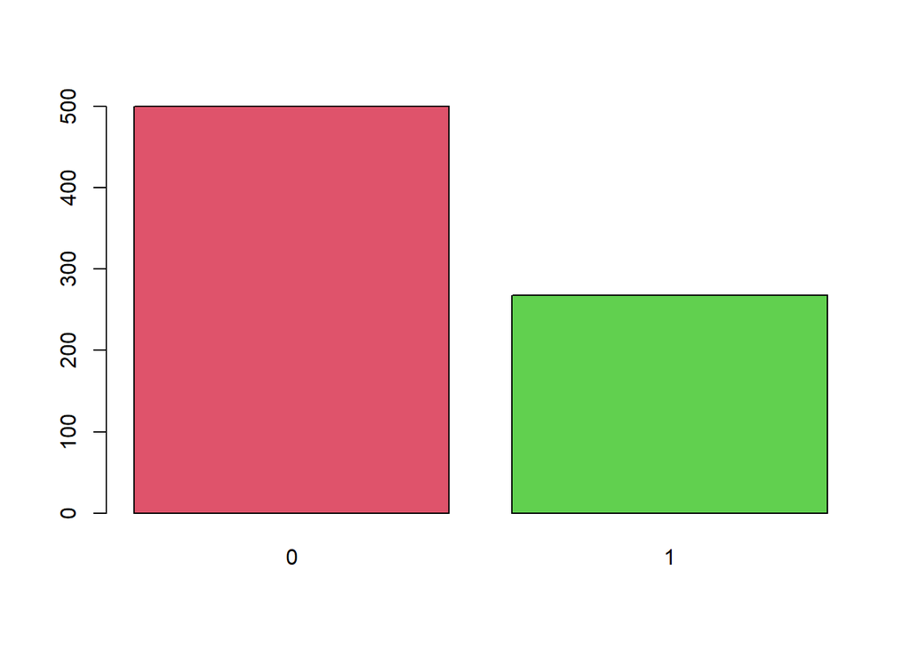

```r
barplot(table(df$Outcome), col = 2:3)
```

## 정상과 환자 평균 비교

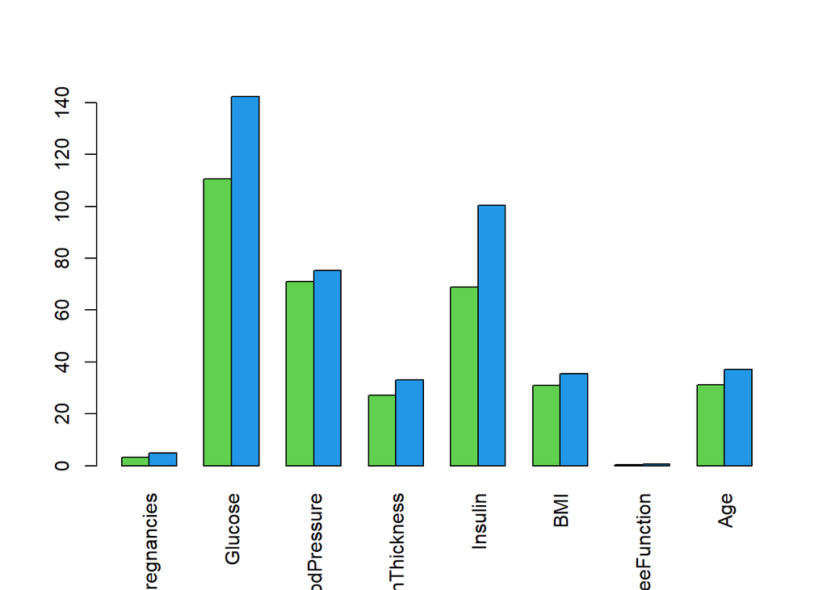

```r
library(psych)
a<-describe(df[df$Outcome==0, ])[,3]
b<-describe(df[df$Outcome==1, ])[,3]

mtrx <- data.frame(x.1 = a[-9], x.2 = b[-9])
mtrx <- as.matrix(mtrx)
mtrx <- t(mtrx)
colnames(mtrx) <- names(df)[-9]
barplot(mtrx, beside=T, col=3:4, las=3)
```

# 그래프 그리기

## 임신 횟수

##### 임신 중에 분비되는 태반 호르몬이 인슐린의 작용을 방해해 발생되는 인슐린 저항성 때문. 보통은 임신성 당뇨병의 경우 출산을 하게 되면 혈당이 정상화 되지만, 이후에 당뇨병으로 진행할 확률이 정상인의 4배

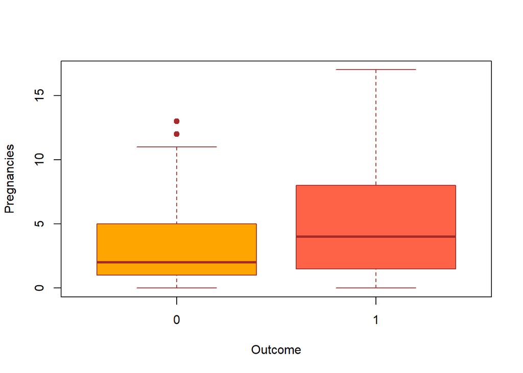

```r
boxplot(Pregnancies ~ Outcome, data = df,
        pch = 19, col = c('orange', 'tomato'), border = 'brown')
```

## 포도당 부하 검사 수치

##### 포도당을 부하했을 때, 당뇨병 환자이면 부하된 포도당을 정상인과 같이 신속하게 혈중에서 제거할 수 없다. 140mg/dL 미만 - 정상

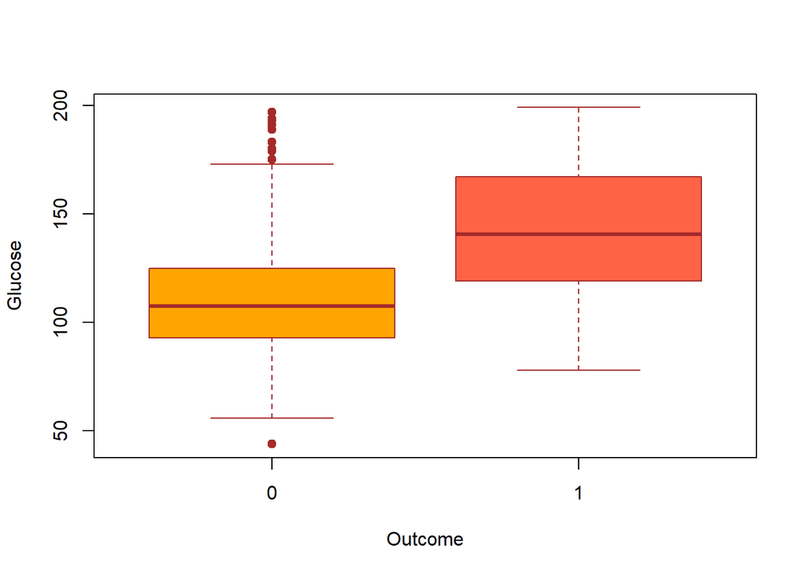

```r
boxplot(Glucose ~ Outcome, data = df,
        pch = 19, col = c('orange', 'tomato'), border = 'brown')
```

## 혈압

##### 인슐린에 대한 세포의 저항성이 고혈압이나 당뇨를 일으키는 원인으로 동일하게 작용하기 때문에 고혈압이 있는 사람은 향후 당뇨가 발생할 가능성이 일반인보다 약 2배 높다.

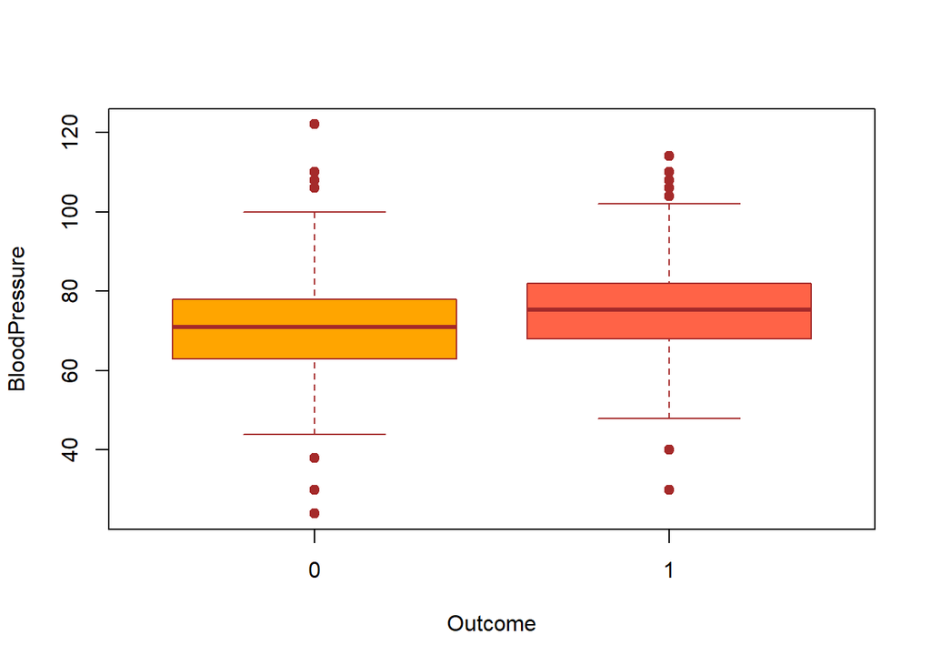

```r
boxplot(BloodPressure ~ Outcome, data = df,
        pch = 19, col = c('orange', 'tomato'), border = 'brown')
```

## 체질량지수(체중(kg)/키(m))^2

##### 비만으로 인해 혈중 유리지방의 수치가 증가하게 되면서, 근육의 포도당 섭취가 저하하게 되고, 이로 인해 인슐린 감도가 약해지고, 또한 간에서 더 많은 포도당을 생산하게 되며 고혈당증을 더욱 부추기게 된다.

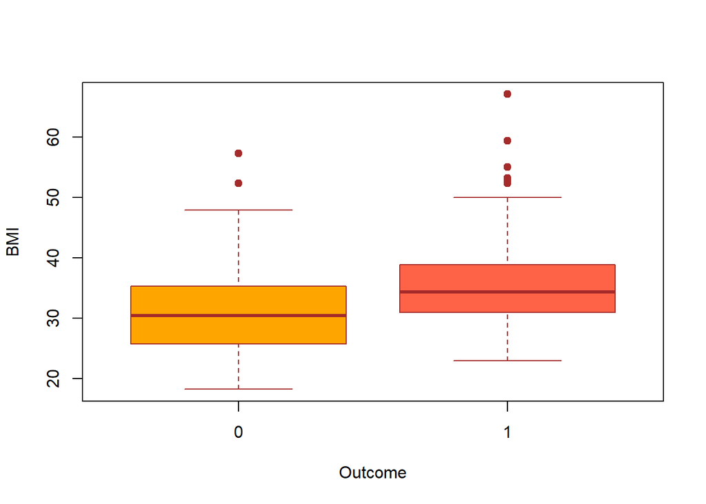

```r
boxplot(BMI ~ Outcome, data = df,
        pch = 19, col = c('orange', 'tomato'), border = 'brown')
```

## 팔 삼두근 뒤쪽의 피하지방 측정값(mm)

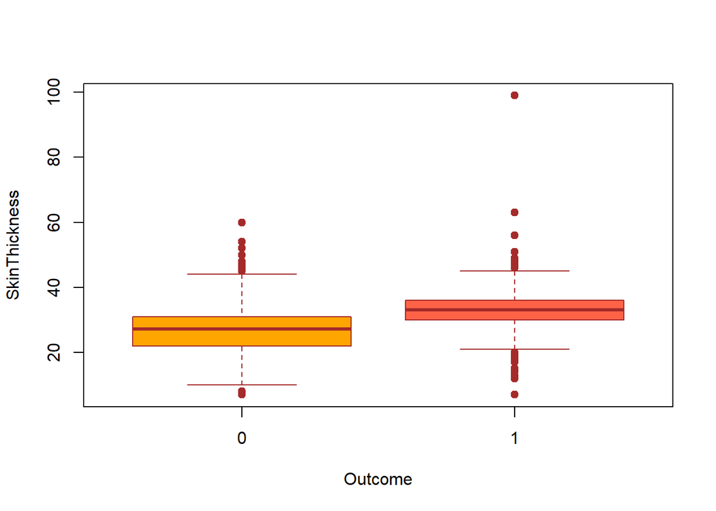

```r
boxplot(SkinThickness ~ Outcome, data = df,
        pch = 19, col = c('orange', 'tomato'), border = 'brown')
```

## 혈청 인슐린(mu U/ml)

##### https://terms.naver.com/entry.naver?docId=500275&cid=60408&categoryId=55558

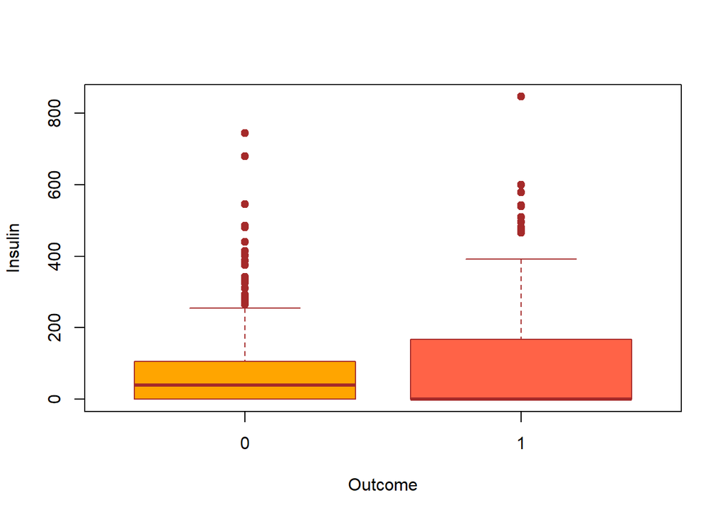

```r
boxplot(Insulin ~ Outcome, data = df,
        pch = 19, col = c('orange', 'tomato'), border = 'brown')
```

## 당뇨 내력 가중치 값

##### 부모가 모두 제2형 당뇨병인 경우 자녀에게서 제2형 당뇨병이 발병할 가능성은 30% 정도, 부모 중 한 사람만 제2형 당뇨병인 경우 자녀에게 제2형 당뇨병이 발병할 가능성은 15% 정도다.

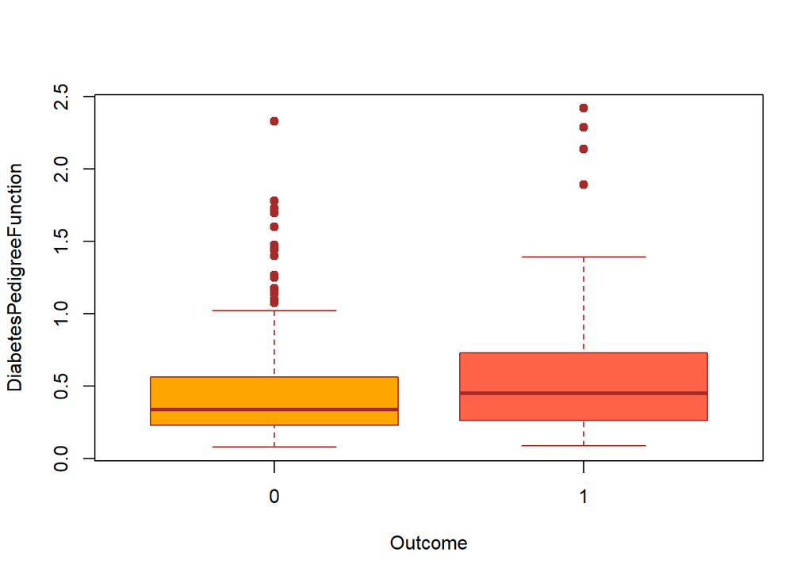

```r
boxplot(DiabetesPedigreeFunction ~ Outcome, data = df,
        pch = 19, col = c('orange', 'tomato'), border = 'brown')
```

## Age: 나이

##### 제1형 당뇨병은 15세 미만의 소아청소년에게 주로 발생하는 당뇨병, 제2형 당뇨병은 30대 이상 주로 발생하는 당뇨병

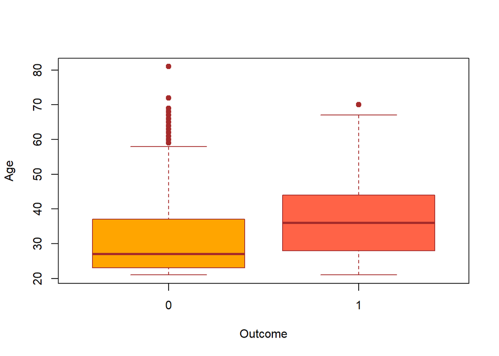

```r
boxplot(Age ~ Outcome, data = df,
        pch = 19, col = c('orange', 'tomato'), border = 'brown')
```

## 환자 수 만큼 정상인 수 샘플링하여 평균 값 비교하기

```r
library(psych)
set.seed(2022)
rows  <- as.numeric(rownames(df[df$Outcome==0,]))
df.origin <- data.frame(Outcome=df[rows,]$Outcome,
                        Pregnancies=df[rows,]$Pregnancies,
                        Glucose=df[rows,]$Glucose,
                        BloodPressure=df[rows,]$BloodPressure,
                        SkinThickness=df[rows,]$SkinThickness,
                        Insulin=df[rows,]$Insulin,
                        BMI=df[rows,]$BMI, DiabetesPedigreeFunction=df[rows,]$DiabetesPedigreeFunction,
                        Age=df[rows,]$Age)

idx <- sample(rows, size=268)
df.sample <- df[idx,]

dfall <- merge(x = df.sample, y = df[df$Outcome==1,], all = T)
df0 <- dfall[dfall$Outcome==0, ]
df1 <- dfall[dfall$Outcome==1, ]

data.frame(name=names(df),mean0=describe(df0)[,3],mean1=describe(df1)[,3], max=describe(dfall)[,9])
```

```
##                       name       mean0      mean1    max
## 1              Pregnancies   3.2537313   4.865672  17.00
## 2                  Glucose 111.2262831 142.319549 199.00
## 3            BloodPressure  71.6455922  75.321429 122.00
## 4            SkinThickness  27.9317815  33.000000  99.00
## 5                  Insulin  63.0485075 100.335821 846.00
## 6                      BMI  31.2466357  35.406767  67.10
## 7 DiabetesPedigreeFunction   0.4304403   0.550500   2.42
## 8                      Age  31.2052239  37.067164  81.00
## 9                  Outcome   1.0000000   2.000000   2.00
```

## 정상과 환자의 포도당 부하 검사 수치와 혈청 인슐린의 산점도 그래프

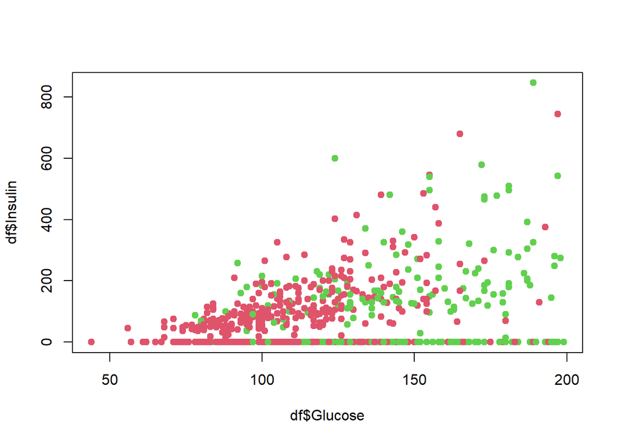

```r
plot(df$Glucose, df$Insulin, pch=19, col=as.numeric(df$Outcome)+1)
```

# 최종 결론

### 모든 변수의 평균이 환자가 높을 것으로 예상한 바와 같다.

### 인슐린 데이터에 문제가 있는 것 같다.

### 정상과 환자의 가장 큰 차이는 포도당 부하 검사 수치와 혈청 인슐린이다.

### 허벅지 근육이 많으면 포도당을 근육세포에 필요로 하기 때문에 혈당이 높아지지 않으므로 허벅지 운동을 하자.